# Supporting Clustering Material

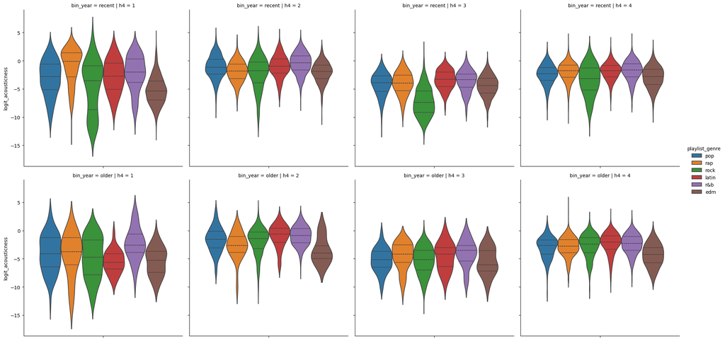

```python
sns.catplot(data=spotify_copy, y='logit_acousticness', hue='playlist_genre', kind='violin', inner='quartile',
            col='h4', row='bin_year')

plt.show()
```

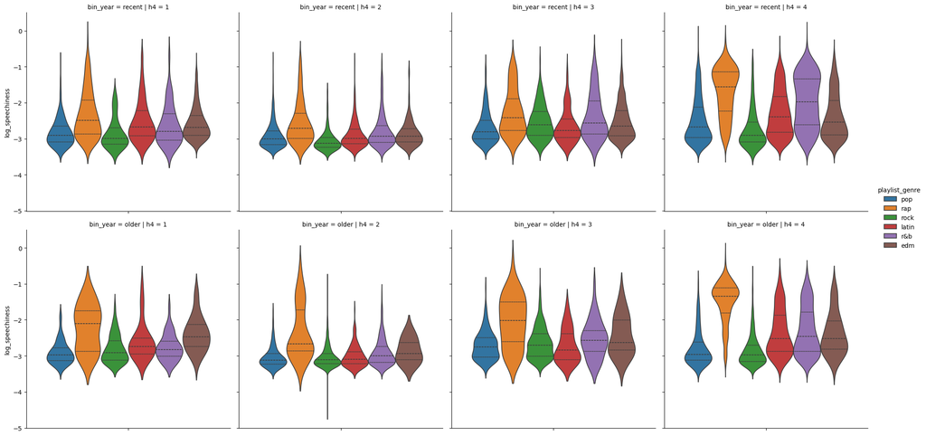

```python
sns.catplot(data=spotify_copy, y='log_speechiness', hue='playlist_genre', kind='violin', inner='quartile',
            col='h4', row='bin_year')

plt.show()
```

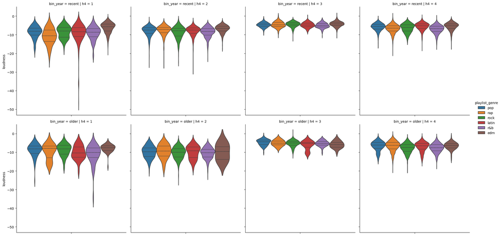

```python
sns.catplot(data=spotify_copy, y='loudness', hue='playlist_genre', kind='violin', inner='quartile',
            col='h4', row='bin_year')

plt.show()
```

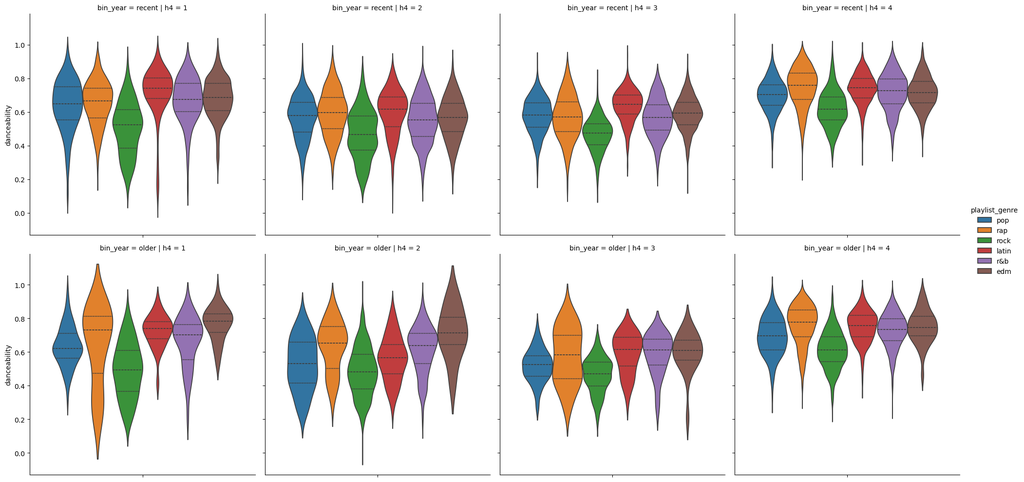

```python
sns.catplot(data=spotify_copy, y='danceability', hue='playlist_genre', kind='violin', inner='quartile',
            col='h4', row='bin_year')

plt.show()
```

Visualize the relationships between `h4` with `mode` and `bin_year`.

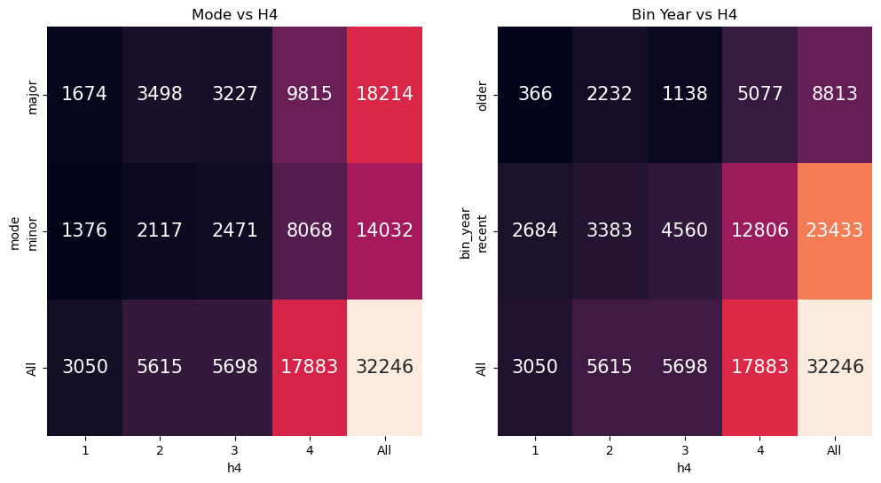

```python
fig, ax = plt.subplots(1, 2, figsize=(12, 6))

sns.heatmap(data=pd.crosstab(spotify_copy['mode'], spotify_copy.h4, margins=True),
            annot=True, annot_kws={'fontsize': 15}, fmt='d',
            cbar=False,
            ax=ax[0])

sns.heatmap(data=pd.crosstab(spotify_copy['bin_year'], spotify_copy.h4, margins=True),
            annot=True, annot_kws={'fontsize': 15}, fmt='d',
            cbar=False,
            ax=ax[1])

ax[0].set_title('Mode vs H4')
ax[1].set_title('Bin Year vs H4')

plt.show()
```

As we can see, there is no strong alignment between any of the cluster groups and `bin_year` or `mode`. This is further supported by the faceted plots.

### Clustering Conclusions

Using PCA followed by Ward’s hierarchical clustering, a four-cluster solution emerged as the most interpretable structure in the data. The clusters were driven primarily by differences in continuous audio features rather than by categorical inputs. Cluster 1 was distinguished by extremely high `instrumentalness`, consistent mid-range `tempo`, and low `log_speechiness`, forming a group of tracks with audio characteristics often associated with EDM or instrumental music. Clusters 2–4 represented vocal tracks with varying degrees of `speechiness`, `energy`, `logit_acousticness`, `loudness`, and `tempo`, but showed less dramatic separation. A heatmap of cluster assignments against `playlist_genre`, `mode`, and `bin_year` confirmed that clusters were distributed across all genres, modes, and years indicating that the clustering captured underlying audio properties rather than categorical labels. Overall, the Ward four-cluster solution effectively summarized meaningful variation in the Spotify audio features and provided a clear, feature-based segmentation of the tracks.